# Контент анализ произведения М.А. Булгакова Мастер и Маргарита

Roman Menyalschikov

04 11 2020

Всего в романе было использовано 4696 слов с положительной эмоциональной окраской и 5279 с отрицательной. Отрицательных на 583 слова больше. Среднее значени по всему произведению положительных слов составлет - 142.3, а отрицательных 159.97. Максимальное количество положительных слов содержится в главе 24 Извлечение мастера (235), так как во время бала сатаны Маргарита смогла увидеть возлюбленного - Мастера. Максимальное количество отрицательных содержится в главе 2 Понтий Пилат (299), так как в ней описывает грозный прокуратор Иудеи.

Анализируя рисунок 1 можно заметить, что распределение эмоционально окрашенных слов волнообразно и в целом количество положительных слов соотвествует количеству отрицательных слов по главам. Из этого распределения можно сделать вывод, что автор в одних главах фиксирует внимание читателя на повествовании, которое содержит больше эмоциаонально окрашенных слов, а в других - на описании, в котором больше нейтральных слов.

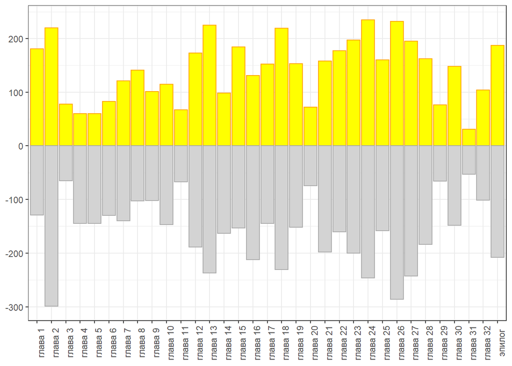

Рис.1 распределение слов с положительным и отрциательным оттенками по главам в романе М.А. Булгакова ‘Мастер и Маргарита’

На рисунке 2 представлено облако слов, которое составлено по первой части романа. Можно заменить, что превалируют имена собственный и глаголы, которые описывают процесс разговора (спросил, ответил). В этой части мы еще не знакомы с Маргаритой и Мастером, поэтому их имен нет в облаке.

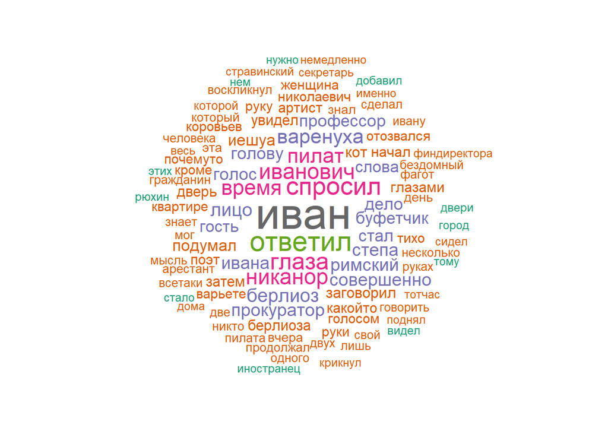

Рис.2 облако слов по первой части романа М.А. Булгакова ‘Мастер и Маргарита’

На рисунке 3 представлено облако слов, которое составлено по второй части романа. Можно заметить, что доминирующие слова - это Маргарита, Воланд и имена его Приспешников. Этим персонажем уделялось наибольшее внимание во второй части романа.

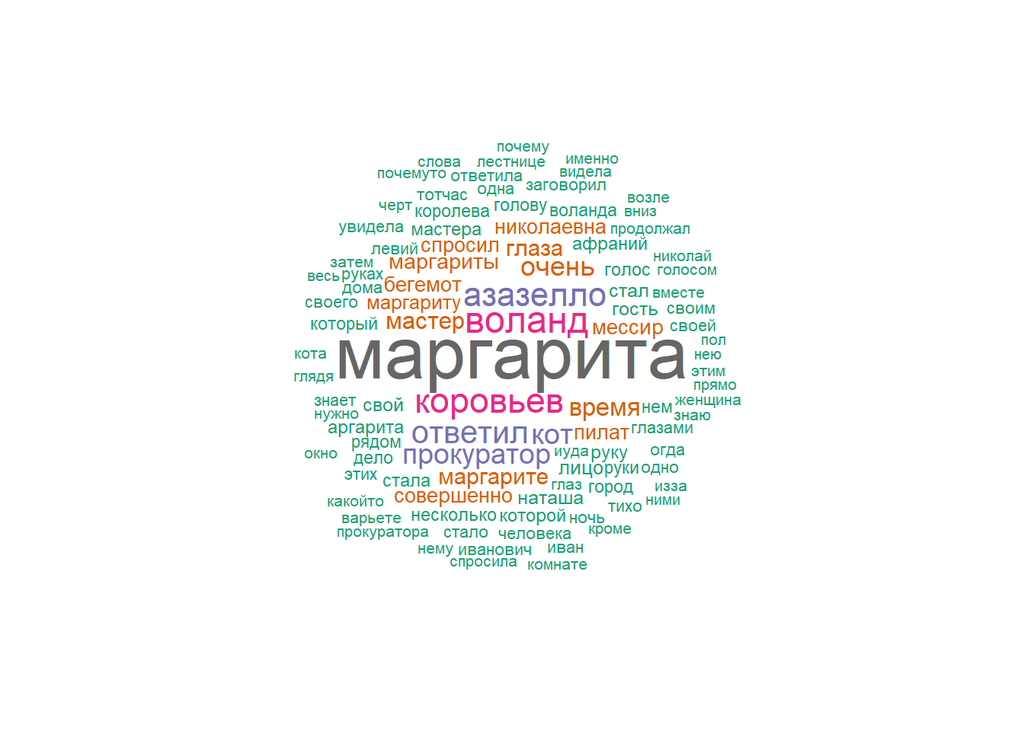

Рис.3 облако слов по второй части романа М.А. Булгакова ‘Мастер и Маргарита’

Таким образом, мы провели небольшой контент анализ романа М.А. Булгакова “Мастер и Маргарита”. Нам удалось проследить закономерное изменение эмоционально окрашенных слов на протяженни всего романа, а таже удалось построить облака слов, которые позволяют оценить наиболее частовстречаемые слова в той или иной главе.